# Data Mining Project

## Importing required packages

```python
import numpy as np
import pandas as pd
import matplotlib.pyplot as plt
import seaborn as sns
from sklearn import tree
from sklearn.tree import DecisionTreeClassifier
from sklearn.ensemble import RandomForestClassifier
from sklearn.neural_network import MLPClassifier
from sklearn.model_selection import train_test_split
from sklearn.metrics import roc_auc_score,roc_curve,classification_report,confusion_matrix
from sklearn.preprocessing import StandardScaler
from sklearn.model_selection import GridSearchCV
```

## Problem 1: Clustering

A leading bank wants to develop a customer segmentation to give promotional offers to its customers. They collected a sample that summarizes the activities of users during the past few months. You are given the task to identify the segments based on credit card usage.

## Data Description

1.spending: Amount spent by the customer per month (in 1000s)

2.advance_payments: Amount paid by the customer in advance by cash (in 100s)

3.probability_of_full_payment: Probability of payment done in full by the customer to the bank

4.current_balance: Balance amount left in the account to make purchases (in 1000s)

5.credit_limit: Limit of the amount in credit card (10000s)

6.min_payment_amt : minimum paid by the customer while making payments for purchases made monthly (in 100s)

7.max_spent_in_single_shopping: Maximum amount spent in one purchase (in 1000s)

### 1.1 Read the data, do the necessary initial steps, and exploratory data analysis (Univariate, Bi-variate, and multivariate analysis).

### Reading the dataset

```python
bank=pd.read_csv('bank_marketing_part1_Data.csv')
```

### Checking the head and tail of dataset

```python
bank.head()
```

|  | spending | advance_payments | probability_of_full_payment | current_balance | credit_limit | min_payment_amt | max_spent_in_single_shopping |
| --- | --- | --- | --- | --- | --- | --- | --- |
| 0 | 19.94 | 16.92 | 0.8752 | 6.675 | 3.763 | 3.252 | 6.550 |
| 1 | 15.99 | 14.89 | 0.9064 | 5.363 | 3.582 | 3.336 | 5.144 |
| 2 | 18.95 | 16.42 | 0.8829 | 6.248 | 3.755 | 3.368 | 6.148 |
| 3 | 10.83 | 12.96 | 0.8099 | 5.278 | 2.641 | 5.182 | 5.185 |
| 4 | 17.99 | 15.86 | 0.8992 | 5.890 | 3.694 | 2.068 | 5.837 |

```python
bank.tail()
```

|  | spending | advance_payments | probability_of_full_payment | current_balance | credit_limit | min_payment_amt | max_spent_in_single_shopping |
| --- | --- | --- | --- | --- | --- | --- | --- |
| 205 | 13.89 | 14.02 | 0.8880 | 5.439 | 3.199 | 3.986 | 4.738 |
| 206 | 16.77 | 15.62 | 0.8638 | 5.927 | 3.438 | 4.920 | 5.795 |
| 207 | 14.03 | 14.16 | 0.8796 | 5.438 | 3.201 | 1.717 | 5.001 |
| 208 | 16.12 | 15.00 | 0.9000 | 5.709 | 3.485 | 2.270 | 5.443 |
| 209 | 15.57 | 15.15 | 0.8527 | 5.920 | 3.231 | 2.640 | 5.879 |

### Shape of Dataset

```python
print('number of rows:',bank.shape[0])
print('number of column:',bank.shape[1])
```

```
number of rows: 210
number of column: 7
```

Dataset contain 210 rows ans 7 columns in dataset

### Checking info

```python
bank.info()
```

```
<class 'pandas.core.frame.DataFrame'>
RangeIndex: 210 entries, 0 to 209
Data columns (total 7 columns):
 #   Column                        Non-Null Count  Dtype
---  ------                        --------------  -----
 0   spending                      210 non-null    float64
 1   advance_payments              210 non-null    float64
 2   probability_of_full_payment   210 non-null    float64
 3   current_balance               210 non-null    float64
 4   credit_limit                  210 non-null    float64
 5   min_payment_amt               210 non-null    float64
 6   max_spent_in_single_shopping  210 non-null    float64
dtypes: float64(7)
memory usage: 11.6 KB
```

### Checking Dtypes

```python
bank.dtypes
```

```
spending                        float64
advance_payments                float64
probability_of_full_payment     float64
current_balance                 float64
credit_limit                    float64
min_payment_amt                 float64
max_spent_in_single_shopping    float64
dtype: object
```

### Checking null values in dataset

```python
bank.isnull().sum().sum()
```

```
0
```

### Checking duplicates in dataset

```python
dups = bank.duplicated()
print('Number of duplicate rows = %d' % (dups.sum()))
bank[dups]
```

```
Number of duplicate rows = 0
```

|  | spending | advance_payments | probability_of_full_payment | current_balance | credit_limit | min_payment_amt | max_spent_in_single_shopping |
| --- | --- | --- | --- | --- | --- | --- | --- |

### Summary of Dataset

```python
round(bank.describe(include='all').T,2)
```

|  | count | mean | std | min | 25% | 50% | 75% | max |
| --- | --- | --- | --- | --- | --- | --- | --- | --- |
| spending | 210.0 | 14.85 | 2.91 | 10.59 | 12.27 | 14.36 | 17.30 | 21.18 |
| advance_payments | 210.0 | 14.56 | 1.31 | 12.41 | 13.45 | 14.32 | 15.72 | 17.25 |
| probability_of_full_payment | 210.0 | 0.87 | 0.02 | 0.81 | 0.86 | 0.87 | 0.89 | 0.92 |
| current_balance | 210.0 | 5.63 | 0.44 | 4.90 | 5.26 | 5.52 | 5.98 | 6.68 |
| credit_limit | 210.0 | 3.26 | 0.38 | 2.63 | 2.94 | 3.24 | 3.56 | 4.03 |
| min_payment_amt | 210.0 | 3.70 | 1.50 | 0.77 | 2.56 | 3.60 | 4.77 | 8.46 |
| max_spent_in_single_shopping | 210.0 | 5.41 | 0.49 | 4.52 | 5.04 | 5.22 | 5.88 | 6.55 |

### Univariate Analysis

```python
def univariateAnalysis_numeric(column):
    print("Description of " + column)
    print("----------------------------------------------------------------------------")
    print(bank[column].describe(),end=' ')


    plt.figure()
    print("Distribution of " + column)
    print("----------------------------------------------------------------------------")
    sns.distplot(bank[column], kde=False, color='g');
    plt.show()

    plt.figure()
    print("BoxPlot of " + column)
    print("----------------------------------------------------------------------------")
    ax = sns.boxplot(x=bank[column])
    plt.show()
```

```python
bank_num = bank.select_dtypes(include = ['float64', 'int64'])
lstnumericcolumns = list(bank_num.columns.values)
len(lstnumericcolumns)
```

```
7
```

```
Description of spending
----------------------------------------------------------------------------
count    210.000000
mean      14.847524
std        2.909699
min       10.590000
25%       12.270000
50%       14.355000
75%       17.305000
max       21.180000
Name: spending, dtype: float64 Distribution of spending
----------------------------------------------------------------------------
```

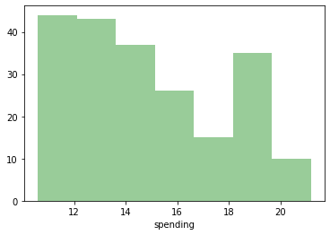

```
BoxPlot of spending
----------------------------------------------------------------------------
```

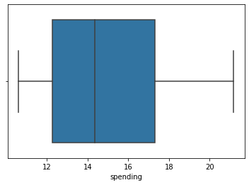

```
Description of advance_payments
----------------------------------------------------------------------------
count    210.000000
mean      14.559286
std        1.305959
min       12.410000
25%       13.450000
50%       14.320000
75%       15.715000
max       17.250000
Name: advance_payments, dtype: float64 Distribution of advance_payments
----------------------------------------------------------------------------
```

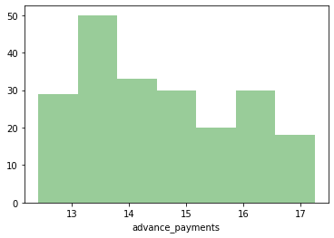

```
BoxPlot of advance_payments
----------------------------------------------------------------------------
```

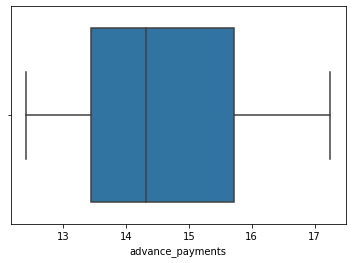

```
Description of probability_of_full_payment
----------------------------------------------------------------------------
count    210.000000
mean       0.870999
std        0.023629
min        0.808100
25%        0.856900
50%        0.873450
75%        0.887775
max        0.918300
Name: probability_of_full_payment, dtype: float64 Distribution of probability_of_full_payment
----------------------------------------------------------------------------
```

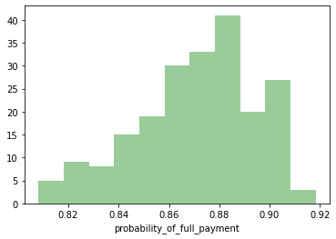

```
BoxPlot of probability_of_full_payment
----------------------------------------------------------------------------
```

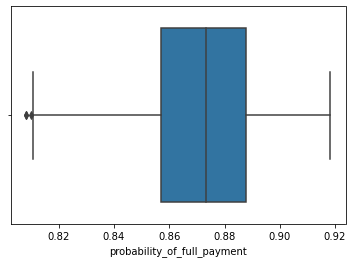

```
Description of current_balance
----------------------------------------------------------------------------
count    210.000000
mean       5.628533
std        0.443063
min        4.899000
25%        5.262250
50%        5.523500
75%        5.979750
max        6.675000
Name: current_balance, dtype: float64 Distribution of current_balance
----------------------------------------------------------------------------
```

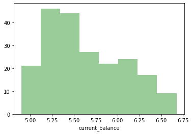

```
BoxPlot of current_balance
----------------------------------------------------------------------------
```

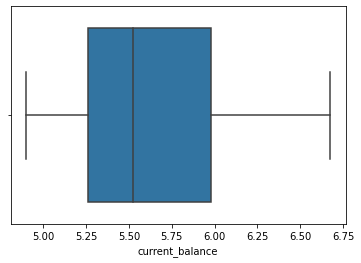

```
Description of credit_limit
----------------------------------------------------------------------------
count    210.000000
mean       3.258605
std        0.377714
min        2.630000
25%        2.944000
50%        3.237000
75%        3.561750
max        4.033000
Name: credit_limit, dtype: float64 Distribution of credit_limit
----------------------------------------------------------------------------
```

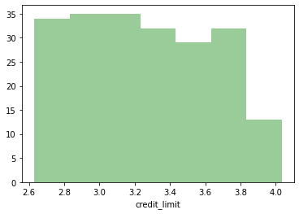

```
BoxPlot of credit_limit
----------------------------------------------------------------------------
```

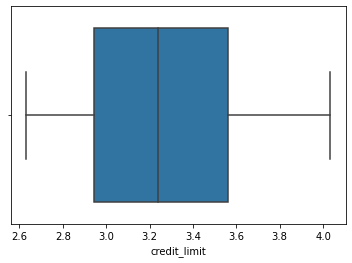

```
Description of min_payment_amt
----------------------------------------------------------------------------
count    210.000000
mean       3.700201
std        1.503557
min        0.765100
25%        2.561500
50%        3.599000
75%        4.768750
max        8.456000
Name: min_payment_amt, dtype: float64 Distribution of min_payment_amt
----------------------------------------------------------------------------
```

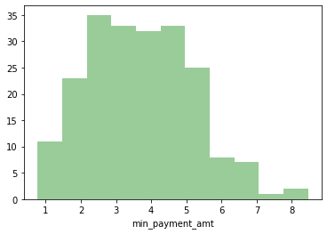

```
BoxPlot of min_payment_amt
----------------------------------------------------------------------------
```

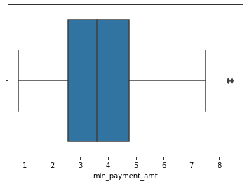

```
Description of max_spent_in_single_shopping
----------------------------------------------------------------------------
count    210.000000
mean       5.408071
std        0.491480
min        4.519000
25%        5.045000
50%        5.223000
75%        5.877000
max        6.550000
Name: max_spent_in_single_shopping, dtype: float64 Distribution of max_spent_in_single_shopping
----------------------------------------------------------------------------
```

[2 more figures not shown]

```python
for x in lstnumericcolumns:
    univariateAnalysis_numeric(x)
```

### Observation:

There are 7 features in dataset.

spending,Advance payment,current balance,credit limit,maxinmum spend in single shopping has no outliers.

Probability of full payement,min amount payement has outliers.

Means and Modes of all features seems to be equal.

spendings ranges from 10.590000 to 21.180000.

Probability of full payement is left skewed.

### Bivariate Analysis

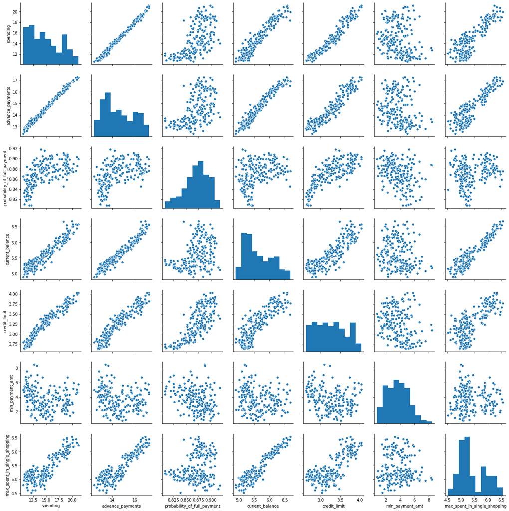

```python
sns.pairplot(data=bank,diag_kind='hist')
plt.show()
```

### Observation:

High spending customers are good with advance payment,maintaining current balance,credit_limit and max_spent_in_single_shopping.

Customer having high current balance spending maximum amount in single shopping

High credit limit customers doing more spendings and advance payement.

### Heatmap

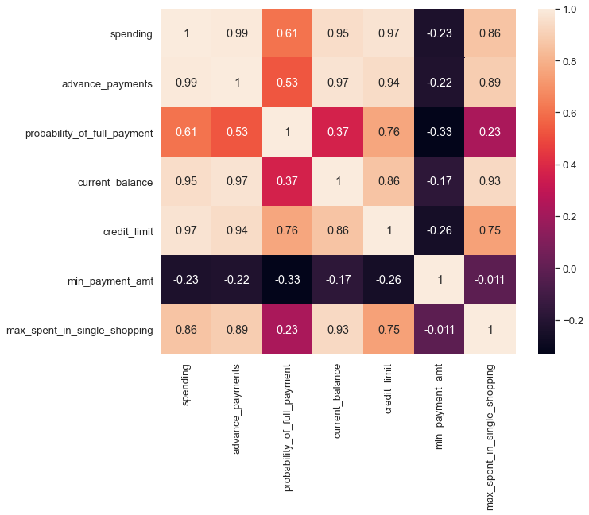

```python
plt.figure(figsize=(10,8))
sns.set(font_scale=1.2)
sns.heatmap(bank[['spending', 'advance_payments', 'probability_of_full_payment','current_balance', 'credit_limit', 'min_payment_amt',
       'max_spent_in_single_shopping']].corr(), annot=True)
```

### Observation:

Current balance are highly correlated with spending, advance_payments,credit_limit and max_spent_in_single_shopping.

Spedings are highly correlated with advance payment,current balance,credit_limit and max_spent_in_single_shopping.

Min payement amount is negatively correlated with all features.

### 1.2 Do you think scaling is necessary for clustering in this case? Justify

### Scaling the data

Yes. Clustering algorithms need feature scaling before they are fed to the algorithm. Since, clustering techniques use Euclidean Distance to form the cohorts, it will be wise.

In clustering, you calculate the similarity between two examples by combining all the feature data for those examples into a numeric value. Combining feature data requires that the data have the same scale.

```python
from sklearn.preprocessing import StandardScaler
```

```python
X = StandardScaler()
```

```python
scaled_df = X.fit_transform(bank)
```

```python
scaled_df = pd.DataFrame(X.fit_transform(bank))
scaled_df.head()
```

|  | 0 | 1 | 2 | 3 | 4 | 5 | 6 |
| --- | --- | --- | --- | --- | --- | --- | --- |
| 0 | 1.754355 | 1.811968 | 0.178230 | 2.367533 | 1.338579 | -0.298806 | 2.328998 |
| 1 | 0.393582 | 0.253840 | 1.501773 | -0.600744 | 0.858236 | -0.242805 | -0.538582 |
| 2 | 1.413300 | 1.428192 | 0.504874 | 1.401485 | 1.317348 | -0.221471 | 1.509107 |
| 3 | -1.384034 | -1.227533 | -2.591878 | -0.793049 | -1.639017 | 0.987884 | -0.454961 |
| 4 | 1.082581 | 0.998364 | 1.196340 | 0.591544 | 1.155464 | -1.088154 | 0.874813 |

### 1.3 Apply hierarchical clustering to scaled data. Identify the number of optimum clusters using Dendrogram and briefly describe them

##### We use scaled data to implementing Wards linkage method for hierarchical clustering

##### For Visualization we use Dentogram

```python
from scipy.cluster.hierarchy import dendrogram, linkage
```

```python
wardlink = linkage(scaled_df, method = 'ward')
```

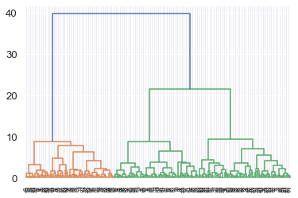

```python
dend = dendrogram(wardlink)
```

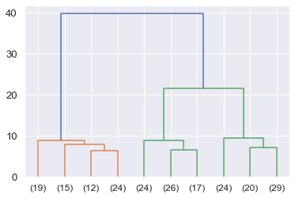

```python
dend = dendrogram(wardlink,truncate_mode='lastp',p = 10)
```

The above dendrogram indicates all the data points have clustered to different clusters by wards method. To find the optimal number cluster through which we can solve our business objective we use truncate mode = lastp. Wherein we can give last p = 10 according to industry set base value.

```python
from scipy.cluster.hierarchy import fcluster
```

```python
clusters = fcluster(wardlink, 3, criterion='maxclust')
clusters
```

```
array([1, 3, 1, 2, 1, 2, 2, 3, 1, 2, 1, 3, 2, 1, 3, 2, 3, 2, 3, 2, 2, 2,
       1, 2, 3, 1, 3, 2, 2, 2, 3, 2, 2, 3, 2, 2, 2, 2, 2, 1, 1, 3, 1, 1,
       2, 2, 3, 1, 1, 1, 2, 1, 1, 1, 1, 1, 2, 2, 2, 1, 3, 2, 2, 3, 3, 1,
       1, 3, 1, 2, 3, 2, 1, 1, 2, 1, 3, 2, 1, 3, 3, 3, 3, 1, 2, 3, 3, 1,
       1, 2, 3, 1, 3, 2, 2, 1, 1, 1, 2, 1, 2, 1, 3, 1, 3, 1, 1, 2, 2, 1,
       3, 3, 1, 2, 2, 1, 3, 3, 2, 1, 3, 2, 2, 2, 3, 3, 1, 2, 3, 3, 2, 3,
       3, 1, 2, 1, 1, 2, 1, 3, 3, 3, 2, 2, 3, 2, 1, 2, 3, 2, 3, 2, 3, 3,
       3, 3, 3, 2, 3, 1, 1, 2, 1, 1, 1, 2, 1, 3, 3, 3, 3, 2, 3, 1, 1, 1,
       3, 3, 1, 2, 3, 3, 3, 3, 1, 1, 3, 3, 3, 2, 3, 3, 2, 1, 3, 1, 1, 2,
       1, 2, 3, 1, 3, 2, 1, 3, 1, 3, 1, 3], dtype=int32)
```

```python
bank['clusters'] = clusters
```

```python
bank.head()
```

|  | spending | advance_payments | probability_of_full_payment | current_balance | credit_limit | min_payment_amt | max_spent_in_single_shopping | clusters |
| --- | --- | --- | --- | --- | --- | --- | --- | --- |
| 0 | 19.94 | 16.92 | 0.8752 | 6.675 | 3.763 | 3.252 | 6.550 | 1 |
| 1 | 15.99 | 14.89 | 0.9064 | 5.363 | 3.582 | 3.336 | 5.144 | 3 |
| 2 | 18.95 | 16.42 | 0.8829 | 6.248 | 3.755 | 3.368 | 6.148 | 1 |
| 3 | 10.83 | 12.96 | 0.8099 | 5.278 | 2.641 | 5.182 | 5.185 | 2 |
| 4 | 17.99 | 15.86 | 0.8992 | 5.890 | 3.694 | 2.068 | 5.837 | 1 |

### AgglomerativeClustering

```python
from sklearn.cluster import AgglomerativeClustering
```

```python
# Set n_clusters=3,affinity='euclidean', linkage='ward' and store the result in another object 'Cluster_agglo'

cluster = AgglomerativeClustering(n_clusters=3, affinity='euclidean', linkage='ward')
Cluster_agglo=cluster.fit_predict(bank.iloc[:,1:7])
print(Cluster_agglo)
```

```
[0 2 0 1 0 1 1 2 0 1 0 2 2 0 2 1 2 1 1 2 1 1 0 2 2 0 2 1 1 1 2 2 1 2 1 1 1
 1 1 0 0 2 0 0 1 1 2 0 0 0 2 0 0 0 0 0 1 1 1 0 2 1 1 0 2 0 0 2 0 2 2 1 0 0
 1 0 2 1 0 2 2 2 2 0 1 2 0 0 0 1 1 0 2 2 2 0 0 0 1 0 1 0 2 0 2 0 0 1 1 0 2
 2 0 1 1 0 2 1 1 0 2 1 1 2 2 2 0 1 2 2 1 2 2 0 1 0 0 1 0 2 0 2 2 2 2 1 0 1
 2 1 2 1 2 2 2 2 2 1 2 0 0 1 0 0 0 1 0 2 2 2 2 1 2 0 0 0 2 2 2 1 2 2 2 2 2
 0 2 2 2 1 2 2 1 0 2 0 0 1 0 1 2 2 2 1 0 2 0 2 2 2]
```

```python
#Appending clusters to original dataset
bank["Agglo_CLusters"]=Cluster_agglo
bank.head()
```

|  | spending | advance_payments | probability_of_full_payment | current_balance | credit_limit | min_payment_amt | max_spent_in_single_shopping | clusters | Agglo_CLusters |
| --- | --- | --- | --- | --- | --- | --- | --- | --- | --- |
| 0 | 19.94 | 16.92 | 0.8752 | 6.675 | 3.763 | 3.252 | 6.550 | 1 | 0 |
| 1 | 15.99 | 14.89 | 0.9064 | 5.363 | 3.582 | 3.336 | 5.144 | 3 | 2 |
| 2 | 18.95 | 16.42 | 0.8829 | 6.248 | 3.755 | 3.368 | 6.148 | 1 | 0 |
| 3 | 10.83 | 12.96 | 0.8099 | 5.278 | 2.641 | 5.182 | 5.185 | 2 | 1 |
| 4 | 17.99 | 15.86 | 0.8992 | 5.890 | 3.694 | 2.068 | 5.837 | 1 | 0 |

```python
bank.Agglo_CLusters.value_counts().sort_index()
```

```
0    69
1    59
2    82
Name: Agglo_CLusters, dtype: int64
```

### 1.4 Apply K-Means clustering on scaled data and determine optimum clusters. Apply elbow curve and silhouette score. Explain the results properly. Interpret and write inferences on the finalized clusters.

### Creating Clusters using KMeans

#### Forming clusters with K = 1,2,3,4,5, and comparing the WSS

```python
from sklearn.cluster import KMeans
```

```python
k_means = KMeans(n_clusters = 1,random_state=1)
k_means.fit(scaled_df)
k_means.inertia_
```

```
1469.9999999999998
```

```python
k_means = KMeans(n_clusters = 2,random_state=1)
k_means.fit(scaled_df)
k_means.inertia_
```

```
659.171754487041
```

```python
k_means = KMeans(n_clusters = 3,random_state=1)
k_means.fit(scaled_df)
k_means.inertia_
```

```
430.6589731513006
```

```python
k_means = KMeans(n_clusters = 4,random_state=1)
k_means.fit(scaled_df)
k_means.inertia_
```

```
371.38509060801096
```

```python
k_means = KMeans(n_clusters = 5,random_state=1)
k_means.fit(scaled_df)
k_means.inertia_
```

```
327.21278165661346
```

#### Calculating WSS for other values of K - Elbow Method

```python
wss =[]
```

```python
for i in range(1,14):
    KM = KMeans(n_clusters=i)
    KM.fit(scaled_df)
    wss.append(KM.inertia_)
```

```python
wss
```

```
[1469.9999999999998,
 659.171754487041,
 430.6589731513006,
 371.1846125351018,
 326.8780629323921,
 289.9983082056098,
 262.2538318184089,
 240.8354319474811,
 223.6544279580454,
 206.24140989763802,
 198.9141197335678,
 180.45649146546356,
 173.6683305682163]
```

```python
a=[1,2,3,4,5,6,7,8,9,10,11,12,13]
```

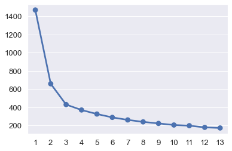

```python
sns.pointplot(a, wss)
```

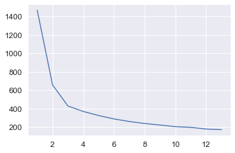

```python
plt.plot(range(1,14), wss)
```

```python
from sklearn.metrics import silhouette_samples, silhouette_score
```

```python
k_means = KMeans(n_clusters = 4,random_state=1)
k_means.fit(scaled_df)
labels = k_means.labels_
```

```python
silhouette_score(scaled_df,labels,random_state=1)
```

```
0.3276547677266193
```

```python
k_means = KMeans(n_clusters = 3,random_state=1)
k_means.fit(scaled_df)
labels = k_means.labels_
```

```python
silhouette_score(scaled_df,labels,random_state=1)
```

```
0.4007270552751299
```

silhouette score is better for 3 clusters when compared to cluster 4. So, final clusters will be 3.

#### Loading cluster to dataset

```python
bank["Clus_kmeans3"] = labels
bank.head()
```

|  | spending | advance_payments | probability_of_full_payment | current_balance | credit_limit | min_payment_amt | max_spent_in_single_shopping | clusters | Agglo_CLusters | Clus_kmeans3 |
| --- | --- | --- | --- | --- | --- | --- | --- | --- | --- | --- |
| 0 | 19.94 | 16.92 | 0.8752 | 6.675 | 3.763 | 3.252 | 6.550 | 1 | 0 | 2 |
| 1 | 15.99 | 14.89 | 0.9064 | 5.363 | 3.582 | 3.336 | 5.144 | 3 | 2 | 0 |
| 2 | 18.95 | 16.42 | 0.8829 | 6.248 | 3.755 | 3.368 | 6.148 | 1 | 0 | 2 |
| 3 | 10.83 | 12.96 | 0.8099 | 5.278 | 2.641 | 5.182 | 5.185 | 2 | 1 | 1 |
| 4 | 17.99 | 15.86 | 0.8992 | 5.890 | 3.694 | 2.068 | 5.837 | 1 | 0 | 2 |

### 1.5 Describe cluster profiles for the clusters defined. Recommend different promotional strategies for different clusters.

### Cluster Profiling for hierarchical clustering

```python
bank['clusters'].value_counts()
```

```
3    73
1    70
2    67
Name: clusters, dtype: int64
```

```python
aggdata=bank.groupby('clusters').mean()
aggdata['Freq']=bank.clusters.value_counts().sort_index()
aggdata.drop(['Clus_kmeans3'],axis=1)
aggdata
```

| clusters | spending | advance_payments | probability_of_full_payment | current_balance | credit_limit | min_payment_amt | max_spent_in_single_shopping | Agglo_CLusters | Clus_kmeans3 | Freq |
| --- | --- | --- | --- | --- | --- | --- | --- | --- | --- | --- |
| 1 | 18.371429 | 16.145429 | 0.884400 | 6.158171 | 3.684629 | 3.639157 | 6.017371 | 0.114286 | 1.885714 | 70 |
| 2 | 11.872388 | 13.257015 | 0.848072 | 5.238940 | 2.848537 | 4.949433 | 5.122209 | 1.164179 | 0.985075 | 67 |
| 3 | 14.199041 | 14.233562 | 0.879190 | 5.478233 | 3.226452 | 2.612181 | 5.086178 | 1.876712 | 0.109589 | 73 |

### Cluster Profiling for K-Means Clustering

```python
bank.Clus_kmeans3.value_counts().sort_index()
```

```
0    71
1    72
2    67
Name: Clus_kmeans3, dtype: int64
```

```python
clust_profile=bank.drop(['clusters','Agglo_CLusters'],axis=1)
clust_profile=clust_profile.groupby('Clus_kmeans3').mean()
clust_profile['freq']=bank.Clus_kmeans3.value_counts().sort_index()
clust_profile
```

| Clus_kmeans3 | spending | advance_payments | probability_of_full_payment | current_balance | credit_limit | min_payment_amt | max_spent_in_single_shopping | freq |
| --- | --- | --- | --- | --- | --- | --- | --- | --- |
| 0 | 14.437887 | 14.337746 | 0.881597 | 5.514577 | 3.259225 | 2.707341 | 5.120803 | 71 |
| 1 | 11.856944 | 13.247778 | 0.848253 | 5.231750 | 2.849542 | 4.742389 | 5.101722 | 72 |
| 2 | 18.495373 | 16.203433 | 0.884210 | 6.175687 | 3.697537 | 3.632373 | 6.041701 | 67 |

Observation:

### Observation:

Hierarchical clustering and K Means clustering is almost equal.

In all clusters customers are good with max_spent_in_single_shopping and probability_of_full_payment

Group 1: High Spending Customer

Giving any reward points might increase their purchases. Bank need to tie up with top brands to provide best offers and cashback to customers  
Maximum max_spent_in_single_shopping is high for this group, so can be offered discount/offer on next transactions upon full payment. Increase their credit limit and – Increase spending habits. Give loan against the credit card, as they are customers with good repayment record.

Group 2: Medium Spending customer:

They are potential target customers who are paying bills and doing purchases and maintaining comparatively good credit score. So we can increase credit limit or can lower down interest rate. - Promote premium cards/loyalty cars to increase transactions. Increase spending habits by trying with premium ecommerce sites, travel portal, travel airlines/hotel, as this will encourage them to spend more.

Group 3: Low Spending Customer:

customers should be given remainders for payments. Offers can be provided on early payments to improve their payment rate. Bank need more concentration on promotions and advertisement cashbacks and offers with more brands to increase the revenue from credit card sector.

### Recomandation:

Bank need to insist customer to use a credit card regularly and responsibly pay off as much as you can every month. ... If you keep your balance reasonably low and make on-time payments every month, you'll contribute to the positive growth of your credit history and scores.

Bank need to encourage customers by explaining Some common advantages of credit card to use regurarly,

..>Paying for purchases over time.

..>Convenience.

..>Credit card rewards.

..>Fraud protection.

..>Free credit scores.

## Problem 2: CART-RF-ANN

An Insurance firm providing tour insurance is facing higher claim frequency. The management decides to collect data from the past few years. You are assigned the task to make a model which predicts the claim status and provide recommendations to management. Use CART, RF & ANN and compare the models' performances in train and test sets.

## Attribute Information:

1. Target: Claim Status (Claimed)
2. Code of tour firm (Agency_Code)
3. Type of tour insurance firms (Type)
4. Distribution channel of tour insurance agencies (Channel)
5. Name of the tour insurance products (Product)
6. Duration of the tour (Duration)
7. Destination of the tour (Destination)
8. Amount of sales of tour insurance policies (Sales)
9. The commission received for tour insurance firm (Commission)
10. Age of insured (Age)

### 2.1 Read the data, do the necessary initial steps, and exploratory data analysis (Univariate, Bi-variate, and multivariate analysis).

### Reading the dataset

```python
insurance=pd.read_csv('insurance_part2_data.csv')
```

### Reading head and tail of dataset

```python
insurance.head()
```

|  | Age | Agency_Code | Type | Claimed | Commision | Channel | Duration | Sales | Product Name | Destination |
| --- | --- | --- | --- | --- | --- | --- | --- | --- | --- | --- |
| 0 | 48 | C2B | Airlines | No | 0.70 | Online | 7 | 2.51 | Customised Plan | ASIA |
| 1 | 36 | EPX | Travel Agency | No | 0.00 | Online | 34 | 20.00 | Customised Plan | ASIA |
| 2 | 39 | CWT | Travel Agency | No | 5.94 | Online | 3 | 9.90 | Customised Plan | Americas |
| 3 | 36 | EPX | Travel Agency | No | 0.00 | Online | 4 | 26.00 | Cancellation Plan | ASIA |
| 4 | 33 | JZI | Airlines | No | 6.30 | Online | 53 | 18.00 | Bronze Plan | ASIA |

```python
insurance.tail()
```

|  | Age | Agency_Code | Type | Claimed | Commision | Channel | Duration | Sales | Product Name | Destination |
| --- | --- | --- | --- | --- | --- | --- | --- | --- | --- | --- |
| 2995 | 28 | CWT | Travel Agency | Yes | 166.53 | Online | 364 | 256.20 | Gold Plan | Americas |
| 2996 | 35 | C2B | Airlines | No | 13.50 | Online | 5 | 54.00 | Gold Plan | ASIA |
| 2997 | 36 | EPX | Travel Agency | No | 0.00 | Online | 54 | 28.00 | Customised Plan | ASIA |
| 2998 | 34 | C2B | Airlines | Yes | 7.64 | Online | 39 | 30.55 | Bronze Plan | ASIA |
| 2999 | 47 | JZI | Airlines | No | 11.55 | Online | 15 | 33.00 | Bronze Plan | ASIA |

## EDA

### Shape of dataset

```python
print('Number of rows:',insurance.shape[0])
print('Number of column:',insurance.shape[1])
```

```
Number of rows: 3000
Number of column: 10
```

### Checking Info of dataset

```python
insurance.info()
```

```
<class 'pandas.core.frame.DataFrame'>
RangeIndex: 3000 entries, 0 to 2999
Data columns (total 10 columns):
 #   Column        Non-Null Count  Dtype
---  ------        --------------  -----
 0   Age           3000 non-null   int64
 1   Agency_Code   3000 non-null   object
 2   Type          3000 non-null   object
 3   Claimed       3000 non-null   object
 4   Commision     3000 non-null   float64
 5   Channel       3000 non-null   object
 6   Duration      3000 non-null   int64
 7   Sales         3000 non-null   float64
 8   Product Name  3000 non-null   object
 9   Destination   3000 non-null   object
dtypes: float64(2), int64(2), object(6)
memory usage: 234.5+ KB
```

### Checking dtypes in dataset

```python
insurance.dtypes
```

```
Age               int64
Agency_Code      object
Type             object
Claimed          object
Commision       float64
Channel          object
Duration          int64
Sales           float64
Product Name     object
Destination      object
dtype: object
```

### Summary the dataset

```python
round(insurance.describe(include='all').T,2)
```

|  | count | unique | top | freq | mean | std | min | 25% | 50% | 75% | max |
| --- | --- | --- | --- | --- | --- | --- | --- | --- | --- | --- | --- |
| Age | 3000 | NaN | NaN | NaN | 38.091 | 10.4635 | 8 | 32 | 36 | 42 | 84 |
| Agency_Code | 3000 | 4 | EPX | 1365 | NaN | NaN | NaN | NaN | NaN | NaN | NaN |
| Type | 3000 | 2 | Travel Agency | 1837 | NaN | NaN | NaN | NaN | NaN | NaN | NaN |
| Claimed | 3000 | 2 | No | 2076 | NaN | NaN | NaN | NaN | NaN | NaN | NaN |
| Commision | 3000 | NaN | NaN | NaN | 14.5292 | 25.4815 | 0 | 0 | 4.63 | 17.235 | 210.21 |
| Channel | 3000 | 2 | Online | 2954 | NaN | NaN | NaN | NaN | NaN | NaN | NaN |
| Duration | 3000 | NaN | NaN | NaN | 70.0013 | 134.053 | -1 | 11 | 26.5 | 63 | 4580 |
| Sales | 3000 | NaN | NaN | NaN | 60.2499 | 70.734 | 0 | 20 | 33 | 69 | 539 |
| Product Name | 3000 | 5 | Customised Plan | 1136 | NaN | NaN | NaN | NaN | NaN | NaN | NaN |
| Destination | 3000 | 3 | ASIA | 2465 | NaN | NaN | NaN | NaN | NaN | NaN | NaN |

### Checking null values

```python
insurance.isnull().sum().sum()
```

```
0
```

### Comparing the unique counts

```python
print('Age \n',insurance.Age.value_counts())
print('\n')
print('Agency_Code \n',insurance.Agency_Code.value_counts())
print('\n')
print('Type \n',insurance.Type.value_counts())
print('\n')
print('Commision \n',insurance.Commision.value_counts())
print('\n')
print('Channel \n',insurance.Channel.value_counts())
print('\n')
print('Duration \n',insurance.Duration.value_counts())
print('\n')
print('Sales \n',insurance.Sales.value_counts())
print('\n')
print('Destination \n',insurance.Destination.value_counts())
print('\n')
print('Claimed \n',insurance.Claimed.value_counts())
```

```
Age
 36    999
31    125
48    108
30     96
35     94
     ...
11      1
84      1
15      1
77      1
8       1
Name: Age, Length: 70, dtype: int64


Agency_Code
 EPX    1365
C2B     924
CWT     472
JZI     239
Name: Agency_Code, dtype: int64


Type
 Travel Agency    1837
Airlines         1163
Name: Type, dtype: int64


Commision
 0.00     1366
63.21      62
54.00      61
23.76      61
7.70       57
         ...
67.75       1
17.29       1
18.13       1
49.40       1
```

[output cut: 36 more lines]

```
271.00      1
Name: Sales, Length: 380, dtype: int64


Destination
 ASIA        2465
Americas     320
EUROPE       215
Name: Destination, dtype: int64


Claimed
 No     2076
Yes     924
Name: Claimed, dtype: int64
```

## univariate Analysis

### Numerical Type

```python
def univariateAnalysis_numeric(column):
    print("Description of " + column)
    print("----------------------------------------------------------------------------")
    print(insurance[column].describe(),end=' ')


    plt.figure()
    print("Distribution of " + column)
    print("----------------------------------------------------------------------------")
    sns.distplot(insurance[column], kde=False, color='g');
    plt.show()

    plt.figure()
    print("BoxPlot of " + column)
    print("----------------------------------------------------------------------------")
    ax = sns.boxplot(x=insurance[column])
    plt.show()
```

```python
insurance_num = insurance.select_dtypes(include = ['float64', 'int64'])
lstnumericcolumns = list(insurance_num.columns.values)
len(lstnumericcolumns)
```

```
4
```

```
Description of Age
----------------------------------------------------------------------------
count    3000.000000
mean       38.091000
std        10.463518
min         8.000000
25%        32.000000
50%        36.000000
75%        42.000000
max        84.000000
Name: Age, dtype: float64 Distribution of Age
----------------------------------------------------------------------------
```

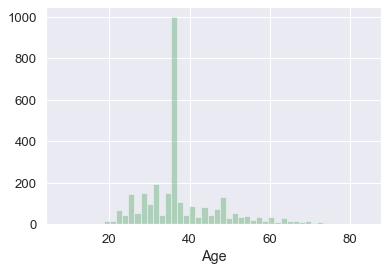

```
BoxPlot of Age
----------------------------------------------------------------------------
```

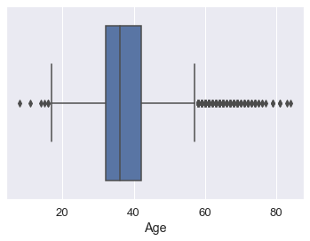

```
Description of Commision
----------------------------------------------------------------------------
count    3000.000000
mean       14.529203
std        25.481455
min         0.000000
25%         0.000000
50%         4.630000
75%        17.235000
max       210.210000
Name: Commision, dtype: float64 Distribution of Commision
----------------------------------------------------------------------------
```

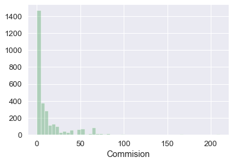

```
BoxPlot of Commision
----------------------------------------------------------------------------
```

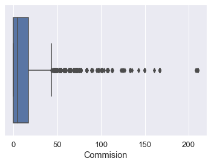

```
Description of Duration
----------------------------------------------------------------------------
count    3000.000000
mean       70.001333
std       134.053313
min        -1.000000
25%        11.000000
50%        26.500000
75%        63.000000
max      4580.000000
Name: Duration, dtype: float64 Distribution of Duration
----------------------------------------------------------------------------
```

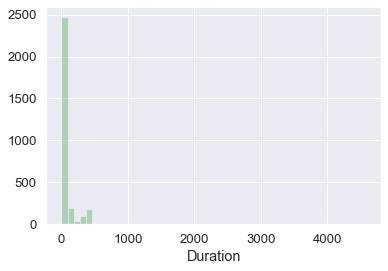

```
BoxPlot of Duration
----------------------------------------------------------------------------
```

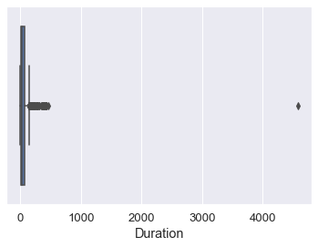

```
Description of Sales
----------------------------------------------------------------------------
count    3000.000000
mean       60.249913
std        70.733954
min         0.000000
25%        20.000000
50%        33.000000
75%        69.000000
max       539.000000
Name: Sales, dtype: float64 Distribution of Sales
----------------------------------------------------------------------------
```

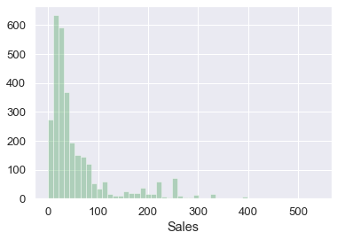

```
BoxPlot of Sales
----------------------------------------------------------------------------
```

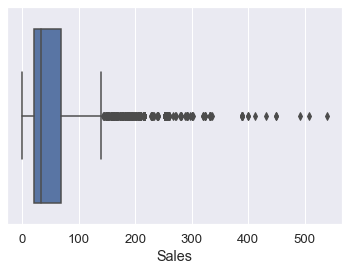

```python
for x in lstnumericcolumns:
    univariateAnalysis_numeric(x)
```

### Observation:

There are four numerical type in dataset.

There are outliers in all the variables. Random Forest and ANN can handle the outliers.

Minimum age is 8 and maximum age is 84.It is positively skewed. Age is distributed more between 30 to 50.

Comossion,sales and duration is right skewed.

### Catagorical Type

```python
def univariateAnalysis_category(column):
    print("Details of " + column)
    print("----------------------------------------------------------------")
    print(insurance[column].value_counts())
    plt.figure()
    insurance[column].value_counts().plot.bar(title="Frequency Distribution of " + column)
    plt.show()
    print("       ")
```

```python
insurance_cat = insurance.select_dtypes(include = ['object'])
lstcatcolumns = list(insurance_cat .columns.values)
lstcatcolumns
```

```
['Agency_Code', 'Type', 'Claimed', 'Channel', 'Product Name', 'Destination']
```

```
Details of Agency_Code
----------------------------------------------------------------
EPX    1365
C2B     924
CWT     472
JZI     239
Name: Agency_Code, dtype: int64
```

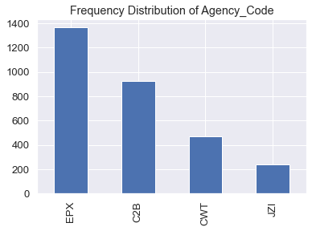

```
Details of Type
----------------------------------------------------------------
Travel Agency    1837
Airlines         1163
Name: Type, dtype: int64
```

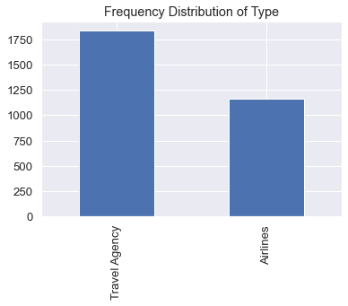

```
Details of Claimed
----------------------------------------------------------------
No     2076
Yes     924
Name: Claimed, dtype: int64
```

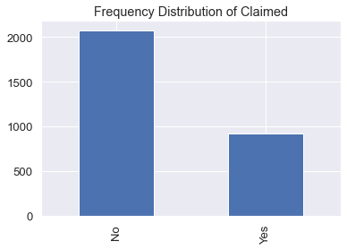

```
Details of Channel
----------------------------------------------------------------
Online     2954
Offline      46
Name: Channel, dtype: int64
```

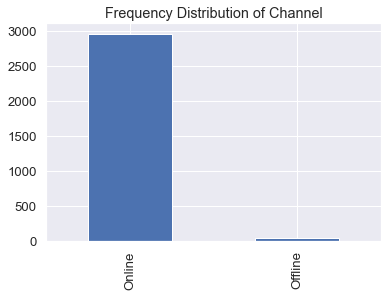

```
Details of Product Name
----------------------------------------------------------------
Customised Plan      1136
Cancellation Plan     678
Bronze Plan           650
Silver Plan           427
Gold Plan             109
Name: Product Name, dtype: int64
```

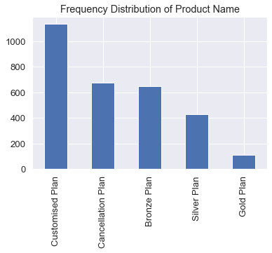

```
Details of Destination
----------------------------------------------------------------
ASIA        2465
Americas     320
EUROPE       215
Name: Destination, dtype: int64
```

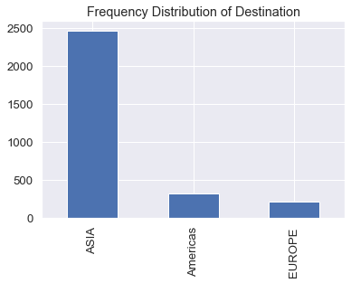

```python
for x in lstcatcolumns:
    univariateAnalysis_category(x)
```

### Observation:

Customers are highly preferred travel agency than airlines.

Customers more preferred to use online platform than offline.

More customers preferred customized plan than less customers choses gold plan.

Asia has preferred more number of customers,second is America and Third is Europe.

## Bivarient Analysis

#### Agency code:

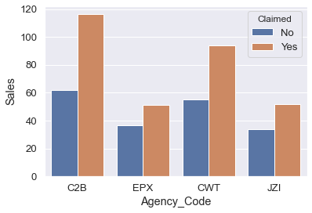

```python
sns.barplot(x='Agency_Code',y='Sales',hue='Claimed',data=insurance,ci=False)
plt.show()
```

### Observation:

The bar plot shows the split of sales with different agency code and also hue having claimed column.

It seems that C2B have claimed more claims than other agency.

#### Type

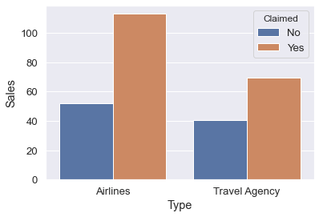

```python
sns.barplot(x='Type',y='Sales',hue='Claimed',data=insurance,ci=False)
plt.show()
```

### Observation:

The bar plot shows the split of sales with different Type and also hue having claimed column.

It seems that airlines have claimed more claims than travel agency.

#### Channel

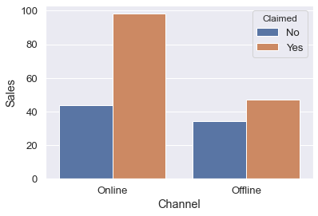

```python
sns.barplot(x='Channel',y='Sales',hue='Claimed',data=insurance,ci=False)
plt.show()
```

#### Observation:

The bar plot shows the split of sales with different channel and also hue having claimed column.

It seems that online have claimed more claims than offline.

#### Product Name

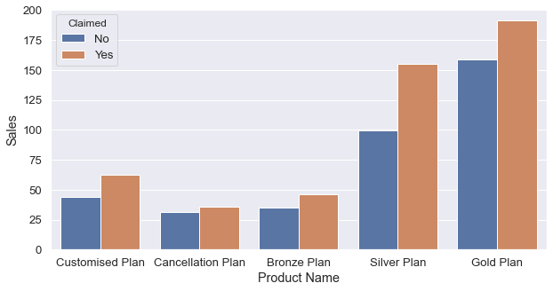

```python
plt.figure(figsize=(10,5))
sns.barplot(x='Product Name',y='Sales',hue='Claimed',data=insurance,ci=False)
plt.show()
```

### Observation:

The bar plot shows the split of sales with different Product name and also hue having claimed column.

Gold plan has Claimed more than products.

Gold plan has less customers but sales rate is high. so agency can get good profit.

#### Destination

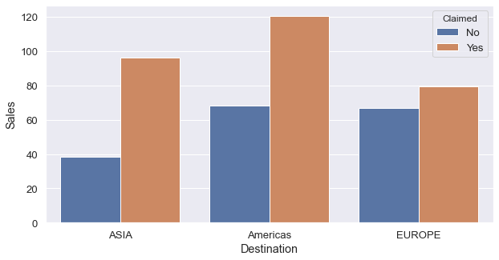

```python
plt.figure(figsize=(10,5))
sns.barplot(x='Destination',y='Sales',hue='Claimed',data=insurance,ci=False)
plt.show()
```

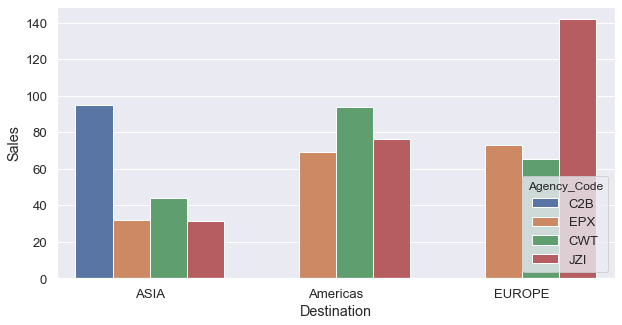

```python
plt.figure(figsize=(10,5))
sns.barplot(x='Destination',y='Sales',hue='Agency_Code',data=insurance,ci=False)
plt.show()
```

### Observation:

The bar plot shows the split of sales with different Destination and also hue having claimed column.

customers who preferred America has Claimed more than other places

Asia has highest frequency of customer but claiming rate is less than America.

None of the customer travel to america and Europe fails to choose C2B agency

### Checking pairwise distribution of the continuous variables

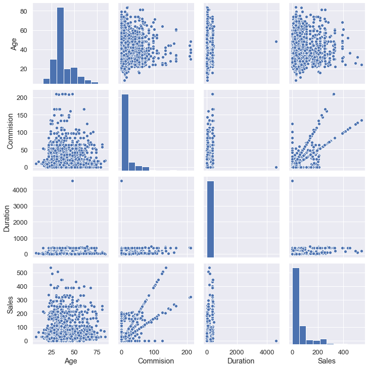

```python
sns.pairplot(insurance[['Age','Commision','Duration','Sales']])
plt.show()
```

### Heat Map

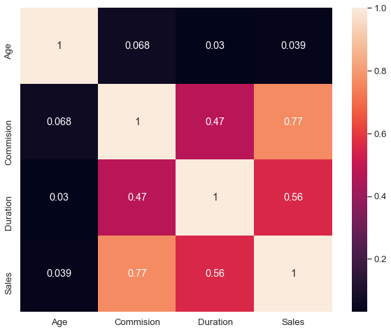

```python
plt.figure(figsize=(10,8))
sns.set(font_scale=1.2)
sns.heatmap(insurance[['Age','Commision','Duration','Sales']].corr(), annot=True)
```

### Observation:

There is no negative correlation

### Converting Object data type into Categorical

```python
for feature in insurance.columns:
    if insurance[feature].dtype == 'object':
        print('\n')
        print('feature:',feature)
        print(pd.Categorical(insurance[feature].unique()))
        print(pd.Categorical(insurance[feature].unique()).codes)
        insurance[feature]=pd.Categorical(insurance[feature]).codes
```

```
feature: Agency_Code
['C2B', 'EPX', 'CWT', 'JZI']
Categories (4, object): ['C2B', 'CWT', 'EPX', 'JZI']
[0 2 1 3]


feature: Type
['Airlines', 'Travel Agency']
Categories (2, object): ['Airlines', 'Travel Agency']
[0 1]


feature: Claimed
['No', 'Yes']
Categories (2, object): ['No', 'Yes']
[0 1]


feature: Channel
['Online', 'Offline']
Categories (2, object): ['Offline', 'Online']
[1 0]


feature: Product Name
['Customised Plan', 'Cancellation Plan', 'Bronze Plan', 'Silver Plan', 'Gold Plan']
Categories (5, object): ['Bronze Plan', 'Cancellation Plan', 'Customised Plan', 'Gold Plan', 'Silver Plan']
[2 1 0 4 3]


feature: Destination
['ASIA', 'Americas', 'EUROPE']
Categories (3, object): ['ASIA', 'Americas', 'EUROPE']
[0 1 2]
```

```python
insurance.head()
```

|  | Age | Agency_Code | Type | Claimed | Commision | Channel | Duration | Sales | Product Name | Destination |
| --- | --- | --- | --- | --- | --- | --- | --- | --- | --- | --- |
| 0 | 48 | 0 | 0 | 0 | 0.70 | 1 | 7 | 2.51 | 2 | 0 |
| 1 | 36 | 2 | 1 | 0 | 0.00 | 1 | 34 | 20.00 | 2 | 0 |
| 2 | 39 | 1 | 1 | 0 | 5.94 | 1 | 3 | 9.90 | 2 | 1 |
| 3 | 36 | 2 | 1 | 0 | 0.00 | 1 | 4 | 26.00 | 1 | 0 |
| 4 | 33 | 3 | 0 | 0 | 6.30 | 1 | 53 | 18.00 | 0 | 0 |

```python
insurance.info()
```

```
<class 'pandas.core.frame.DataFrame'>
RangeIndex: 3000 entries, 0 to 2999
Data columns (total 10 columns):
 #   Column        Non-Null Count  Dtype
---  ------        --------------  -----
 0   Age           3000 non-null   int64
 1   Agency_Code   3000 non-null   int8
 2   Type          3000 non-null   int8
 3   Claimed       3000 non-null   int8
 4   Commision     3000 non-null   float64
 5   Channel       3000 non-null   int8
 6   Duration      3000 non-null   int64
 7   Sales         3000 non-null   float64
 8   Product Name  3000 non-null   int8
 9   Destination   3000 non-null   int8
dtypes: float64(2), int64(2), int8(6)
memory usage: 111.5 KB
```

### Proportion of observations in Target classes

```python
insurance['Claimed'].value_counts(normalize=True)
```

```
0    0.692
1    0.308
Name: Claimed, dtype: float64
```

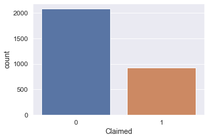

```python
sns.countplot(insurance['Claimed'])
plt.show()
```

There is no issue of class imbalance here as we have reasonable proportions in both the classes

### 2.2 Data Split: Split the data into test and train, build classification model CART, Random Forest, Artificial Neural Network

### Extracting the target column into separate vectors for training set and test set

```python
X = insurance.drop(['Claimed'], axis=1)

y = insurance.pop("Claimed")

X.head()
```

|  | Age | Agency_Code | Type | Commision | Channel | Duration | Sales | Product Name | Destination |
| --- | --- | --- | --- | --- | --- | --- | --- | --- | --- |
| 0 | 48 | 0 | 0 | 0.70 | 1 | 7 | 2.51 | 2 | 0 |
| 1 | 36 | 2 | 1 | 0.00 | 1 | 34 | 20.00 | 2 | 0 |
| 2 | 39 | 1 | 1 | 5.94 | 1 | 3 | 9.90 | 2 | 1 |
| 3 | 36 | 2 | 1 | 0.00 | 1 | 4 | 26.00 | 1 | 0 |
| 4 | 33 | 3 | 0 | 6.30 | 1 | 53 | 18.00 | 0 | 0 |

### Splitting data into training and test set

```python
from sklearn.model_selection import train_test_split

X_train, X_test, train_labels, test_labels = train_test_split(X, y, test_size=.30, random_state=1)
```

### Checking the dimensions of the training and test data

```python
print('X_train',X_train.shape)
print('X_test',X_test.shape)
print('train_labels',train_labels.shape)
print('test_labels',test_labels.shape)
```

```
X_train (2100, 9)
X_test (900, 9)
train_labels (2100,)
test_labels (900,)
```

### 2.3 Performance Metrics: Comment and Check the performance of Predictions on Train and Test sets using Accuracy, Confusion Matrix, Plot ROC curve and get ROC_AUC score, classification reports for each model.

## Building a Decision Tree Classifier

```python
#Initializing Decision Tree
dt_model = DecisionTreeClassifier(criterion = 'gini', random_state=1)
```

```python
# Fit the model
dt_model.fit(X_train, train_labels)
```

```
DecisionTreeClassifier(random_state=1)
```

```python
from sklearn import tree
```

```python
train_char_label = ['No', 'Yes']
Insurance_Tree_File = open('d:\Insurance_tree.dot','w')
dot_data = tree.export_graphviz(dt_model, out_file=Insurance_Tree_File, feature_names = list(X_train), class_names = list(train_char_label))

Insurance_Tree_File.close()
```

```python
param_grid = {
    'criterion': ['gini'],
    'max_depth': [10,20,30,50],
    'min_samples_leaf': [50,100,150],
    'min_samples_split': [150,300,450],
}

dtcl = DecisionTreeClassifier(random_state=1)

grid_search = GridSearchCV(estimator = dtcl, param_grid = param_grid, cv = 10)
```

```python
grid_search.fit(X_train, train_labels)
```

```
GridSearchCV(cv=10, estimator=DecisionTreeClassifier(random_state=1),
             param_grid={'criterion': ['gini'], 'max_depth': [10, 20, 30, 50],
                         'min_samples_leaf': [50, 100, 150],
                         'min_samples_split': [150, 300, 450]})
```

```python
grid_search.best_params_
```

```
{'criterion': 'gini',
 'max_depth': 10,
 'min_samples_leaf': 50,
 'min_samples_split': 150}
```

```python
best_grid_cart = grid_search.best_estimator_
```

```python
ytrain_predict_cart = best_grid_cart.predict(X_train)
ytest_predict_cart= best_grid_cart.predict(X_test)
```

```python
ytest_predict_cart
ytest_predict_cart_prob=best_grid_cart.predict_proba(X_test)
ytest_predict_cart_prob
pd.DataFrame(ytest_predict_cart_prob).head()
```

|  | 0 | 1 |
| --- | --- | --- |
| 0 | 0.935714 | 0.064286 |
| 1 | 0.529412 | 0.470588 |
| 2 | 0.358621 | 0.641379 |
| 3 | 0.234783 | 0.765217 |
| 4 | 0.924242 | 0.075758 |

## Prediction on Decision Tree Classifier

### Prediction of Training Dataset

```python
ytrain_predict_cart = best_grid_cart.predict(X_train)
print('ytrain_predict_cart:',ytrain_predict_cart.shape)
```

```
ytrain_predict_cart: (2100,)
```

#### Accuracy:

```python
cart_train_acc=best_grid_cart.score(X_train,train_labels)
print('Accuracy:',round(cart_train_acc,2))
```

```
Accuracy: 0.79
```

#### classification report

```python
print(classification_report(train_labels,ytrain_predict_cart))
```

```
              precision    recall  f1-score   support

           0       0.81      0.92      0.86      1471
           1       0.72      0.50      0.59       629

    accuracy                           0.79      2100
   macro avg       0.77      0.71      0.73      2100
weighted avg       0.78      0.79      0.78      2100
```

#### Confusion matrix

```python
confusion_matrix(train_labels, ytrain_predict_cart)
```

```
array([[1349,  122],
       [ 313,  316]], dtype=int64)
```

```python
cart_metrics=classification_report(train_labels, ytrain_predict_cart,output_dict=True)
df=pd.DataFrame(cart_metrics).transpose()
cart_train_f1=round(df.loc["1"][2],2)
cart_train_recall=round(df.loc["1"][1],2)
cart_train_precision=round(df.loc["1"][0],2)
print ('cart_train_precision ',cart_train_precision)
print ('cart_train_recall ',cart_train_recall)
print ('cart_train_f1 ',cart_train_f1)
```

```
cart_train_precision  0.72
cart_train_recall  0.5
cart_train_f1  0.59
```

#### ROC curve and ROC_AUC score:

```
AUC: 0.836
```

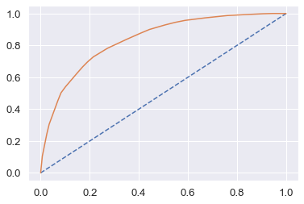

```python
# predict probabilities
probs = best_grid_cart.predict_proba(X_train)
# keep probabilities for the positive outcome only
probs = probs[:, 1]
# calculate AUC
cart_train_auc = roc_auc_score(train_labels, probs)
print('AUC: %.3f' % cart_train_auc)
# calculate roc curve
cart_train_fpr, cart_train_tpr, cart_train_thresholds = roc_curve(train_labels, probs)
plt.plot([0, 1], [0, 1], linestyle='--')
# plot the roc curve for the model
plt.plot(cart_train_fpr, cart_train_tpr)
```

### Prediction of Test Dataset

```python
ytest_predict_cart = best_grid_cart.predict(X_test)
print('ytest_predict_cart:',ytest_predict_cart.shape)
```

```
ytest_predict_cart: (900,)
```

#### Accuracy:

```python
cart_test_acc=best_grid_cart.score(X_test,test_labels)
print('Accuracy:',round(cart_test_acc,2))
```

```
Accuracy: 0.75
```

#### confusion_matrix:

```python
confusion_matrix(test_labels, ytest_predict_cart)
```

```
array([[564,  41],
       [183, 112]], dtype=int64)
```

#### classification_report:

```python
print(classification_report(test_labels,ytest_predict_cart))
```

```
              precision    recall  f1-score   support

           0       0.76      0.93      0.83       605
           1       0.73      0.38      0.50       295

    accuracy                           0.75       900
   macro avg       0.74      0.66      0.67       900
weighted avg       0.75      0.75      0.72       900
```

```python
cart_metrics=classification_report(test_labels, ytest_predict_cart,output_dict=True)
df=pd.DataFrame(cart_metrics).transpose()
cart_test_precision=round(df.loc["1"][0],2)
cart_test_recall=round(df.loc["1"][1],2)
cart_test_f1=round(df.loc["1"][2],2)
print ('cart_test_precision ',cart_test_precision)
print ('cart_test_recall ',cart_test_recall)
print ('cart_test_f1 ',cart_test_f1)
```

```
cart_test_precision  0.73
cart_test_recall  0.38
cart_test_f1  0.5
```

#### ROC curve and ROC_AUC score:

```
AUC: 0.794
```

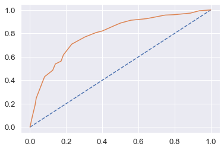

```python
# predict probabilities
probs = best_grid_cart.predict_proba(X_test)
# keep probabilities for the positive outcome only
probs = probs[:, 1]
# calculate AUC
cart_test_auc = roc_auc_score(test_labels, probs)
print('AUC: %.3f' % cart_test_auc)
# calculate roc curve
cart_test_fpr, cart_test_tpr, cart_testthresholds = roc_curve(test_labels, probs)
plt.plot([0, 1], [0, 1], linestyle='--')
# plot the roc curve for the model
plt.plot(cart_test_fpr, cart_test_tpr)
```

#### Cart conclution:

##### Train Data:

Accuracy: 79%

AUC: 84%

Recall:50%

Precision: 72%

f1-Score: 59%

#### Test Data:

Accuracy: 75%

AUC: 79%

Recall:38%

Precision: 73%

f1-Score: 50%

## Building a Random Forest Model

```python
param_grid = {
    'max_depth': [10],## 20,30,40
    'max_features': [4],## 7,8,9
    'min_samples_leaf': [10],## 20,50,100
    'min_samples_split': [80], ## 60,70
    'n_estimators': [300] ## 100,200
}

rfcl = RandomForestClassifier(random_state=1)

grid_search = GridSearchCV(estimator = rfcl, param_grid = param_grid, cv = 10)
```

```python
grid_search.fit(X_train, train_labels)
```

```
GridSearchCV(cv=10, estimator=RandomForestClassifier(random_state=1),
             param_grid={'max_depth': [10], 'max_features': [4],
                         'min_samples_leaf': [10], 'min_samples_split': [80],
                         'n_estimators': [300]})
```

```python
grid_search.best_params_
```

```
{'max_depth': 10,
 'max_features': 4,
 'min_samples_leaf': 10,
 'min_samples_split': 80,
 'n_estimators': 300}
```

```python
best_grid_rf = grid_search.best_estimator_
```

```python
ytrain_predict_rf = best_grid_rf.predict(X_train)
ytest_predict_rf = best_grid_rf.predict(X_test)
```

## Prediction on Random Forest Model

### Prediction of Training Dataset

```python
ytrain_predict_rf = best_grid_rf.predict(X_train)
print('ytrain_predict_rf:',ytrain_predict_rf.shape)
```

```
ytrain_predict_rf: (2100,)
```

#### Accuracy:

```python
rf_train_acc=best_grid_rf.score(X_train,train_labels)
rf_train_acc
```

```
0.8066666666666666
```

#### Confusion Matrix:

```python
confusion_matrix(train_labels,ytrain_predict_rf)
```

```
array([[1327,  144],
       [ 262,  367]], dtype=int64)
```

#### classification reports:

```python
print(classification_report(train_labels,ytrain_predict_rf))
```

```
              precision    recall  f1-score   support

           0       0.84      0.90      0.87      1471
           1       0.72      0.58      0.64       629

    accuracy                           0.81      2100
   macro avg       0.78      0.74      0.76      2100
weighted avg       0.80      0.81      0.80      2100
```

```python
rf_metrics=classification_report(train_labels, ytrain_predict_rf,output_dict=True)
df=pd.DataFrame(rf_metrics).transpose()
rf_train_precision=round(df.loc["1"][0],2)
rf_train_recall=round(df.loc["1"][1],2)
rf_train_f1=round(df.loc["1"][2],2)
print ('rf_train_precision ',rf_train_precision)
print ('rf_train_recall ',rf_train_recall)
print ('rf_train_f1 ',rf_train_f1)
```

```
rf_train_precision  0.72
rf_train_recall  0.58
rf_train_f1  0.64
```

#### ROC curve and ROC_AUC score:

```
Area under Curve is 0.8584920546571284
```

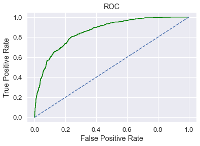

```python
rf_train_fpr, rf_train_tpr,_=roc_curve(train_labels,best_grid_rf.predict_proba(X_train)[:,1])
plt.plot(rf_train_fpr,rf_train_tpr,color='green')
plt.plot([0, 1], [0, 1], linestyle='--')
plt.xlabel('False Positive Rate')
plt.ylabel('True Positive Rate')
plt.title('ROC')
rf_train_auc=roc_auc_score(train_labels,best_grid_rf.predict_proba(X_train)[:,1])
print('Area under Curve is', rf_train_auc)
```

### Prediction of Test Dataset

```python
ytest_predict_rf = best_grid_rf.predict(X_test)
print('ytest_predict_rf:',ytest_predict_rf.shape)
```

```
ytest_predict_rf: (900,)
```

#### Accuracy:

```python
rf_test_acc=best_grid_rf.score(X_test,test_labels)
rf_test_acc
```

```
0.7688888888888888
```

#### Confusion Matrix:

```python
confusion_matrix(test_labels,ytest_predict_rf)
```

```
array([[553,  52],
       [156, 139]], dtype=int64)
```

#### classification reports:

```python
print(classification_report(test_labels,ytest_predict_rf))
```

```
              precision    recall  f1-score   support

           0       0.78      0.91      0.84       605
           1       0.73      0.47      0.57       295

    accuracy                           0.77       900
   macro avg       0.75      0.69      0.71       900
weighted avg       0.76      0.77      0.75       900
```

```python
rf_metrics=classification_report(test_labels,ytest_predict_rf,output_dict=True)
df=pd.DataFrame(rf_metrics).transpose()
rf_test_precision=round(df.loc["1"][0],2)
rf_test_recall=round(df.loc["1"][1],2)
rf_test_f1=round(df.loc["1"][2],2)
print ('rf_test_precision ',rf_test_precision)
print ('rf_test_recall ',rf_test_recall)
print ('rf_test_f1 ',rf_test_f1)
```

```
rf_test_precision  0.73
rf_test_recall  0.47
rf_test_f1  0.57
```

#### ROC curve and ROC_AUC score:

```
Area under Curve is 0.8221599663818461
```

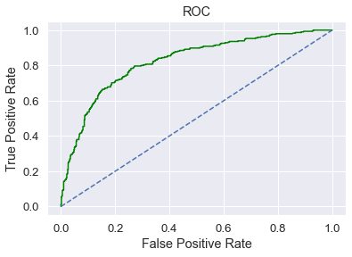

```python
rf_test_fpr, rf_test_tpr,_=roc_curve(test_labels,best_grid_rf.predict_proba(X_test)[:,1])
plt.plot(rf_test_fpr,rf_test_tpr,color='green')
plt.plot([0, 1], [0, 1], linestyle='--')
plt.xlabel('False Positive Rate')
plt.ylabel('True Positive Rate')
plt.title('ROC')
rf_test_auc=roc_auc_score(test_labels,best_grid_rf.predict_proba(X_test)[:,1])
print('Area under Curve is', rf_test_auc)
```

#### Random Forest conclution:

##### Train Data:

Accuracy: 81%

AUC: 86%

Recall:58%

Precision: 72%

f1-Score: 64%

##### Test Data:

Accuracy: 77%

AUC: 82%

Recall:47%

Precision: 73%

f1-Score: 57%

## Building a Neural Networks

```python
from sklearn.preprocessing import StandardScaler
```

```python
#Initialize an object for StandardScaler
sc = StandardScaler()
```

```python
#Scale the training data
X_train = sc.fit_transform(X_train)
```

```python
X_train=pd.DataFrame(X_train)
round(X_train.head(),2)
```

|  | 0 | 1 | 2 | 3 | 4 | 5 | 6 | 7 | 8 |
| --- | --- | --- | --- | --- | --- | --- | --- | --- | --- |
| 0 | -0.19 | 0.73 | 0.81 | -0.58 | 0.12 | -0.29 | -0.57 | 0.25 | -0.44 |
| 1 | -0.19 | 0.73 | 0.81 | -0.58 | 0.12 | 0.46 | -0.27 | 0.25 | 1.28 |
| 2 | -0.97 | -1.29 | -1.24 | 1.22 | 0.12 | 2.03 | 1.75 | 1.83 | -0.44 |
| 3 | -0.97 | -1.29 | -1.24 | -0.12 | 0.12 | -0.29 | -0.18 | 1.83 | -0.44 |
| 4 | 0.98 | -0.28 | 0.81 | 0.13 | 0.12 | -0.13 | -0.17 | 1.04 | -0.44 |

```python
param_grid = {
    'hidden_layer_sizes': [200], # 50, 200
    'max_iter': [2500], #5000,2500
    'solver': ['adam'], #sgd
    'tol': [0.01],
}

nncl = MLPClassifier(random_state=1)

grid_search = GridSearchCV(estimator = nncl, param_grid = param_grid, cv = 10)
```

```python
grid_search.fit(X_train, train_labels)
grid_search.best_params_
```

```
{'hidden_layer_sizes': 200, 'max_iter': 2500, 'solver': 'adam', 'tol': 0.01}
```

```python
best_grid_ann = grid_search.best_estimator_
best_grid_ann
```

```
MLPClassifier(hidden_layer_sizes=200, max_iter=2500, random_state=1, tol=0.01)
```

```python
ytrain_predict_ann = best_grid_ann.predict(X_train)
ytest_predict_ann = best_grid_ann.predict(X_test)
```

## Prediction on Neural Network

### Prediction of Training Dataset

```python
ytrain_predict_ann = best_grid_ann.predict(X_train)
print('ytrain_predict_ann:',ytrain_predict_ann.shape)
```

```
ytrain_predict_ann: (2100,)
```

#### Accuracy:

```python
nn_train_acc=best_grid_ann.score(X_train,train_labels)
nn_train_acc
```

```
0.7757142857142857
```

#### Confusion Matrix:

```python
confusion_matrix(train_labels,ytrain_predict_ann)
```

```
array([[1311,  160],
       [ 311,  318]], dtype=int64)
```

#### classification reports:

```python
print(classification_report(train_labels,ytrain_predict_ann))
```

```
              precision    recall  f1-score   support

           0       0.81      0.89      0.85      1471
           1       0.67      0.51      0.57       629

    accuracy                           0.78      2100
   macro avg       0.74      0.70      0.71      2100
weighted avg       0.77      0.78      0.77      2100
```

```python
nn_metrics=classification_report(train_labels, ytrain_predict_ann,output_dict=True)
df=pd.DataFrame(nn_metrics).transpose()
nn_train_precision=round(df.loc["1"][0],2)
nn_train_recall=round(df.loc["1"][1],2)
nn_train_f1=round(df.loc["1"][2],2)
print ('nn_train_precision ',nn_train_precision)
print ('nn_train_recall ',nn_train_recall)
print ('nn_train_f1 ',nn_train_f1)
```

```
nn_train_precision  0.67
nn_train_recall  0.51
nn_train_f1  0.57
```

#### ROC curve and ROC_AUC score:

```
Area under Curve is 0.8182460262477858
```

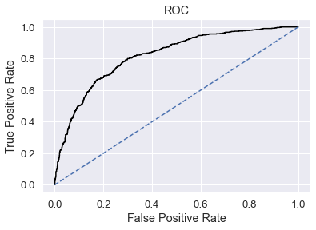

```python
nn_train_fpr, nn_train_tpr,_=roc_curve(train_labels,best_grid_ann.predict_proba(X_train)[:,1])
plt.plot(nn_train_fpr,nn_train_tpr,color='black')
plt.plot([0, 1], [0, 1], linestyle='--')
plt.xlabel('False Positive Rate')
plt.ylabel('True Positive Rate')
plt.title('ROC')
nn_train_auc=roc_auc_score(train_labels,best_grid_ann.predict_proba(X_train)[:,1])
print('Area under Curve is', nn_train_auc)
```

## Prediction of Test Dataset

#### Accuracy:

```python
nn_test_acc=best_grid_ann.score(X_test,test_labels)
nn_test_acc
```

```
0.5966666666666667
```

#### Confusion Matrix:

```python
confusion_matrix(test_labels,ytest_predict_ann)
```

```
array([[350, 255],
       [108, 187]], dtype=int64)
```

#### classification reports:

```python
print(classification_report(test_labels,ytest_predict_ann))
```

```
              precision    recall  f1-score   support

           0       0.76      0.58      0.66       605
           1       0.42      0.63      0.51       295

    accuracy                           0.60       900
   macro avg       0.59      0.61      0.58       900
weighted avg       0.65      0.60      0.61       900
```

```python
nn_metrics=classification_report(test_labels, ytest_predict_ann,output_dict=True)
df=pd.DataFrame(nn_metrics).transpose()
nn_test_precision=round(df.loc["1"][0],2)
nn_test_recall=round(df.loc["1"][1],2)
nn_test_f1=round(df.loc["1"][2],2)
print ('nn_test_precision ',nn_test_precision)
print ('nn_test_recall ',nn_test_recall)
print ('nn_test_f1 ',nn_test_f1)
```

```
nn_test_precision  0.42
nn_test_recall  0.63
nn_test_f1  0.51
```

#### ROC curve and ROC_AUC score:

```
Area under Curve is 0.6270149880935705
```

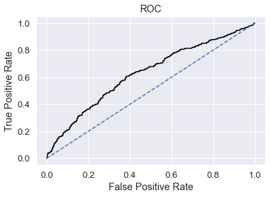

```python
nn_test_fpr, nn_test_tpr,_=roc_curve(test_labels,best_grid_ann.predict_proba(X_test)[:,1])
plt.plot(nn_test_fpr,nn_test_tpr,color='black')
plt.plot([0, 1], [0, 1], linestyle='--')
plt.xlabel('False Positive Rate')
plt.ylabel('True Positive Rate')
plt.title('ROC')
nn_test_auc=roc_auc_score(test_labels,best_grid_ann.predict_proba(X_test)[:,1])
print('Area under Curve is', nn_test_auc)
```

#### Neural Network conclution:

##### Train Data:

Accuracy: 78%

AUC: 82%

Recall:51%

Precision: 67%

f1-Score: 57%

##### Test Data:

Accuracy: 60%

AUC: 63%

Recall:63%

Precision: 42%

f1-Score: 51%

### 2.4 Final Model: Compare all the models and write an inference which model is best/optimized.

#### Comparison of the performance metrics from the 3 models

```python
index=['Accuracy', 'AUC', 'Recall','Precision','F1 Score']
data = pd.DataFrame({'CART Train':[cart_train_acc,cart_train_auc,cart_train_recall,cart_train_precision,cart_train_f1],
        'CART Test':[cart_test_acc,cart_test_auc,cart_test_recall,cart_test_precision,cart_test_f1],
       'Random Forest Train':[rf_train_acc,rf_train_auc,rf_train_recall,rf_train_precision,rf_train_f1],
        'Random Forest Test':[rf_test_acc,rf_test_auc,rf_test_recall,rf_test_precision,rf_test_f1],
       'Neural Network Train':[nn_train_acc,nn_train_auc,nn_train_recall,nn_train_precision,nn_train_f1],
        'Neural Network Test':[nn_test_acc,nn_test_auc,nn_test_recall,nn_test_precision,nn_test_f1]},index=index)
round(data,2)
```

|  | CART Train | CART Test | Random Forest Train | Random Forest Test | Neural Network Train | Neural Network Test |
| --- | --- | --- | --- | --- | --- | --- |
| Accuracy | 0.79 | 0.75 | 0.81 | 0.77 | 0.78 | 0.60 |
| AUC | 0.84 | 0.79 | 0.86 | 0.82 | 0.82 | 0.63 |
| Recall | 0.50 | 0.38 | 0.58 | 0.47 | 0.51 | 0.63 |
| Precision | 0.72 | 0.73 | 0.72 | 0.73 | 0.67 | 0.42 |
| F1 Score | 0.59 | 0.50 | 0.64 | 0.57 | 0.57 | 0.51 |

### Observation

#### ROC Curve for the 3 models on the Training data

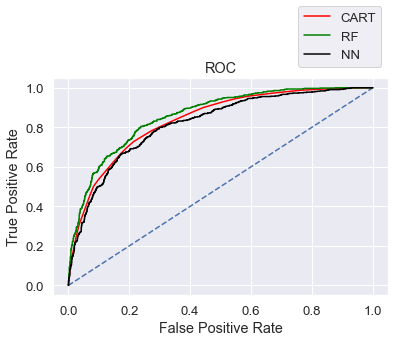

```python
plt.plot([0, 1], [0, 1], linestyle='--')
plt.plot(cart_train_fpr, cart_train_tpr,color='red',label="CART")
plt.plot(rf_train_fpr,rf_train_tpr,color='green',label="RF")
plt.plot(nn_train_fpr,nn_train_tpr,color='black',label="NN")
plt.xlabel('False Positive Rate')
plt.ylabel('True Positive Rate')
plt.title('ROC')
plt.legend(bbox_to_anchor=(0., 1.02, 1., .102), loc='lower right')
```

#### ROC Curve for the 3 models on the Test data

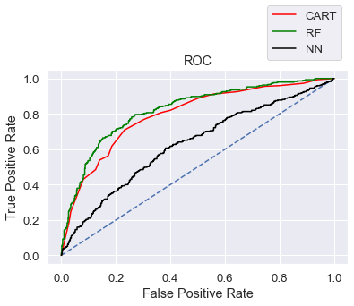

```python
plt.plot([0, 1], [0, 1], linestyle='--')
plt.plot(cart_test_fpr, cart_test_tpr,color='red',label="CART")
plt.plot(rf_test_fpr,rf_test_tpr,color='green',label="RF")
plt.plot(nn_test_fpr,nn_test_tpr,color='black',label="NN")
plt.xlabel('False Positive Rate')
plt.ylabel('True Positive Rate')
plt.title('ROC')
plt.legend(bbox_to_anchor=(0., 1.02, 1., .102), loc='lower right')
```

### 2.5 Inference: Based on the whole Analysis, what are the business insights and recommendations

Looking at the data, we need more data which will help us for better understand and predict the model in better way.

JZI agency has low frequency of customers when compared to other agencies. So they should concentrate more on sales by giving advertisement and promotional campaign to increase the revenue.

98% of customer chooses online platform than offline, So online experiance is better for customers we need to streamline in proper way which will be hassle free for customers. They can interact more customers in online, which will subsequently increase the revenue. Interesting fact is they providing insurance claim on offline business also...

Travel Agency has high frequency of customers compared to airlines.Interesting fact is customer preferred airlines claiming rate is higher than customer prefered travel agency. So we need to evaluate why travel agency has low insurance claiming?..Need to overcome this situation to increase the revenue through travel agency.

Customised Plan,Bronze Plan,Cancellation Plan has high customer frequencies but low claiming rate.so we need to work on marketing statergies to increase the sale in insurance claims .

Silver Plan,Gold Plan has low customer frequecies but high claiming rate. we need to intract more customer in both plans so we can get more insurance claims so it will increase trhe revenue part.

Interesing fact is none of the customer travel to America and Europe has not prefered C2B Agency but C2B agency are good with claiming rate. So need to focus on customers who travel to america and Europe to increase the revenue.

Key performance indicators (KPI) of insurance claims are

```
Increase customer satisfaction which in fact will give more revenue.

Regular feedback from customers and need to evaluate within tat.

Need to reduce fraud transactions, deploy measures to avoid fraudulent transactions at earliest.

Optimize claims recovery method.

Reduce claim handling costs for customers.
```

FAQ should be upto date so customer can refer if they get any struck in online platform and they should have good customer support to handle the customers it will genrate good revenue.